# Exercise 5

Hanna Julku

# 5: Dimentionality reduction techniques

## Human data set

```r
# load libraries to be used
library(tidyverse)
```

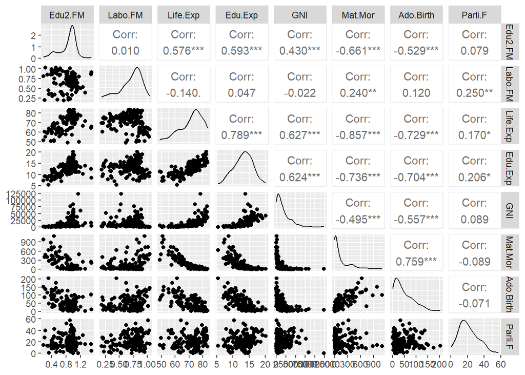

```r
library(corrplot)
library(GGally)
library(ggplot2)

# read the data into a data frame
human <- read.csv(file = "\\\\ad.helsinki.fi/home/h/hkonstar/Desktop/IDOS/IODS-project/data/human.csv", row.names = 1) %>% as.data.frame()

#visualize data and show summary
ggpairs(human)
```

```r
summary(human)
```

```
##     Edu2.FM          Labo.FM          Life.Exp        Edu.Exp
##  Min.   :0.1717   Min.   :0.1857   Min.   :49.00   Min.   : 5.40
##  1st Qu.:0.7264   1st Qu.:0.5984   1st Qu.:66.30   1st Qu.:11.25
##  Median :0.9375   Median :0.7535   Median :74.20   Median :13.50
##  Mean   :0.8529   Mean   :0.7074   Mean   :71.65   Mean   :13.18
##  3rd Qu.:0.9968   3rd Qu.:0.8535   3rd Qu.:77.25   3rd Qu.:15.20
##  Max.   :1.4967   Max.   :1.0380   Max.   :83.50   Max.   :20.20
##       GNI            Mat.Mor         Ado.Birth         Parli.F
##  Min.   :   581   Min.   :   1.0   Min.   :  0.60   Min.   : 0.00
##  1st Qu.:  4198   1st Qu.:  11.5   1st Qu.: 12.65   1st Qu.:12.40
##  Median : 12040   Median :  49.0   Median : 33.60   Median :19.30
##  Mean   : 17628   Mean   : 149.1   Mean   : 47.16   Mean   :20.91
##  3rd Qu.: 24512   3rd Qu.: 190.0   3rd Qu.: 71.95   3rd Qu.:27.95
##  Max.   :123124   Max.   :1100.0   Max.   :204.80   Max.   :57.50
```

```r
str(human)
```

```
## 'data.frame':    155 obs. of  8 variables:
##  $ Edu2.FM  : num  1.007 0.997 0.983 0.989 0.969 ...
##  $ Labo.FM  : num  0.891 0.819 0.825 0.884 0.829 ...
##  $ Life.Exp : num  81.6 82.4 83 80.2 81.6 80.9 80.9 79.1 82 81.8 ...
##  $ Edu.Exp  : num  17.5 20.2 15.8 18.7 17.9 16.5 18.6 16.5 15.9 19.2 ...
##  $ GNI      : int  64992 42261 56431 44025 45435 43919 39568 52947 42155 32689 ...
##  $ Mat.Mor  : int  4 6 6 5 6 7 9 28 11 8 ...
##  $ Ado.Birth: num  7.8 12.1 1.9 5.1 6.2 3.8 8.2 31 14.5 25.3 ...
##  $ Parli.F  : num  39.6 30.5 28.5 38 36.9 36.9 19.9 19.4 28.2 31.4 ...
```

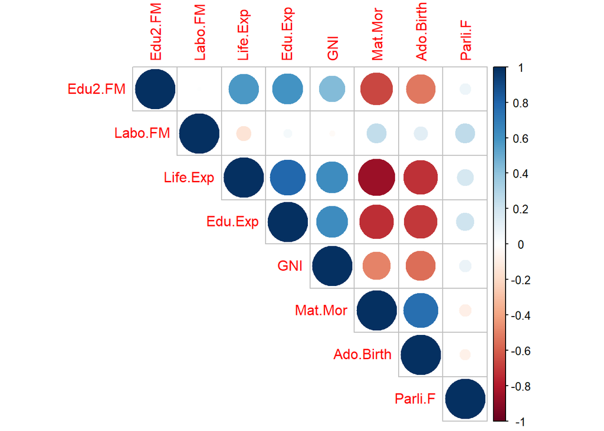

```r
cor(human) %>% corrplot(, type = "upper")
```

There are 8 variables and 155 observations in the data set. Variable distributions vary a lot. Some follow normal distribution, others do not. Life.Exp and Edu.Exp as well as Mat.Mor and Ado.Birth have the highest positive correlation. Life.Exp and Mat.Mor on the hand have highest negative correlation. Just mentioned two “clusters” (Life.Exp + Edu.Exp and Mat.Mor + Ado.Birth) correlate negatively with each other.

## Principal component analysis (PCA)

```r
# perform principal component analysis (with the SVD method)
pca_human <- prcomp(human)

# Show the variability captured by the principal components.
summary(pca_human)
```

```
## Importance of components:
##                              PC1      PC2   PC3   PC4   PC5   PC6    PC7    PC8
## Standard deviation     1.854e+04 185.5219 25.19 11.45 3.766 1.566 0.1912 0.1591
## Proportion of Variance 9.999e-01   0.0001  0.00  0.00 0.000 0.000 0.0000 0.0000
## Cumulative Proportion  9.999e-01   1.0000  1.00  1.00 1.000 1.000 1.0000 1.0000
```

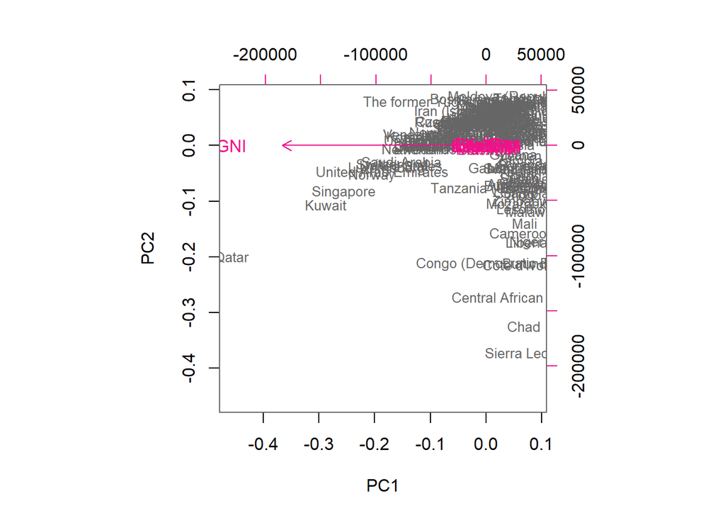

```r
# draw a biplot of the principal component representation and the original variables
biplot(pca_human, choices = 1:2, cex = c(0.8, 1), col = c("grey40", "deeppink2"))
```

Data was not standardized, so let’s standardize it and redo what was just done.

```r
# standardize data
human_std <- scale(human)

# perform principal component analysis (with the SVD method)
pca_human_std <- prcomp(human_std)

# Show the variability captured by the principal components.
summary(pca_human_std)
```

```
## Importance of components:
##                           PC1    PC2     PC3     PC4     PC5     PC6     PC7
## Standard deviation     2.0708 1.1397 0.87505 0.77886 0.66196 0.53631 0.45900
## Proportion of Variance 0.5361 0.1624 0.09571 0.07583 0.05477 0.03595 0.02634
## Cumulative Proportion  0.5361 0.6984 0.79413 0.86996 0.92473 0.96069 0.98702
##                            PC8
## Standard deviation     0.32224
## Proportion of Variance 0.01298
## Cumulative Proportion  1.00000
```

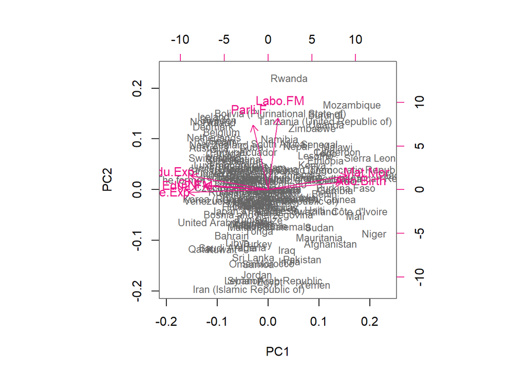

```r
# draw a biplot of the principal component representation and the original variables
biplot(pca_human_std, choices = 1:2, cex = c(0.8, 1), col = c("grey40", "deeppink2"))
```

Standardization makes it possible to compare variables with each other. Standardized results resemble visualized data, whereas non-standardized results were quite different. For instance, non-standardized biplot shows GNI as the most impactfull variable, where as for the standardized data results resemble correlations for original data. Standardized results give more defined results.

Life expectancy, female/male proportion having secondary education, expected year of education, and Gross national income appear together and they have an opposite effect than maternal mortality and number of children being born. These relate to PC1 that explains the most of the variance in the data that is about 54% in this case. Female/male proportion on participating in labour and women representation in parliament have similar effect. These explain about 16% of the variance in the data, and they are mostly related to PC2.

## Tea data set

```r
# load tea data set
tea <- read.csv("https://raw.githubusercontent.com/KimmoVehkalahti/Helsinki-Open-Data-Science/master/datasets/tea.csv", stringsAsFactors = TRUE) %>% as.data.frame()

#explore the data
str(tea)
```

```
## 'data.frame':    300 obs. of  36 variables:
##  $ breakfast       : Factor w/ 2 levels "breakfast","Not.breakfast": 1 1 2 2 1 2 1 2 1 1 ...
##  $ tea.time        : Factor w/ 2 levels "Not.tea time",..: 1 1 2 1 1 1 2 2 2 1 ...
##  $ evening         : Factor w/ 2 levels "evening","Not.evening": 2 2 1 2 1 2 2 1 2 1 ...
##  $ lunch           : Factor w/ 2 levels "lunch","Not.lunch": 2 2 2 2 2 2 2 2 2 2 ...
##  $ dinner          : Factor w/ 2 levels "dinner","Not.dinner": 2 2 1 1 2 1 2 2 2 2 ...
##  $ always          : Factor w/ 2 levels "always","Not.always": 2 2 2 2 1 2 2 2 2 2 ...
##  $ home            : Factor w/ 2 levels "home","Not.home": 1 1 1 1 1 1 1 1 1 1 ...
##  $ work            : Factor w/ 2 levels "Not.work","work": 1 1 2 1 1 1 1 1 1 1 ...
##  $ tearoom         : Factor w/ 2 levels "Not.tearoom",..: 1 1 1 1 1 1 1 1 1 2 ...
##  $ friends         : Factor w/ 2 levels "friends","Not.friends": 2 2 1 2 2 2 1 2 2 2 ...
##  $ resto           : Factor w/ 2 levels "Not.resto","resto": 1 1 2 1 1 1 1 1 1 1 ...
##  $ pub             : Factor w/ 2 levels "Not.pub","pub": 1 1 1 1 1 1 1 1 1 1 ...
##  $ Tea             : Factor w/ 3 levels "black","Earl Grey",..: 1 1 2 2 2 2 2 1 2 1 ...
##  $ How             : Factor w/ 4 levels "alone","lemon",..: 1 3 1 1 1 1 1 3 3 1 ...
```

[output cut: 22 more lines]

```r
dim(tea)
```

```
## [1] 300  36
```

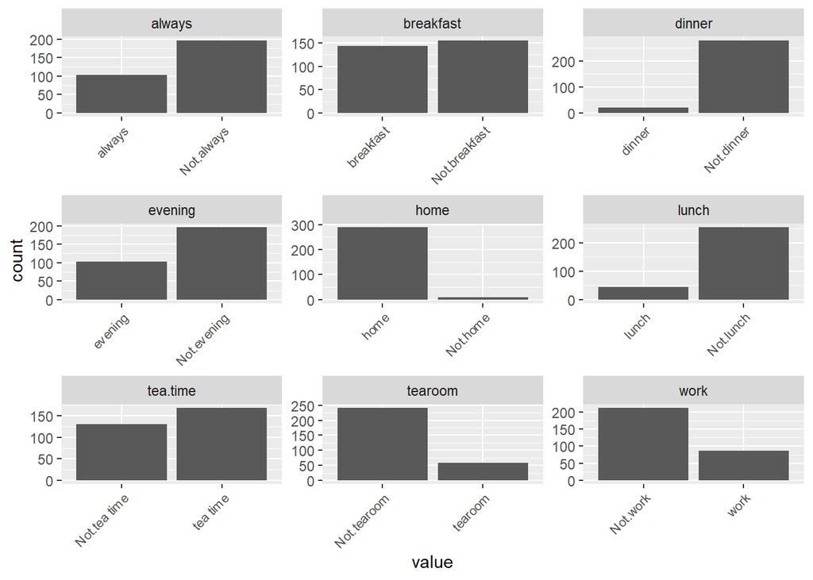

```r
view(tea)

#rselect subsets to be drawn
tea1 <- tea[,1:9] %>% as.data.frame()
tea2 <- tea[,10:18] %>% as.data.frame()
tea3 <- tea[,20:29] %>% as.data.frame()
tea4 <- tea[,30:36] %>% as.data.frame()

#visualize  data
pivot_longer(tea1, cols = everything()) %>%
  ggplot(aes(value)) + facet_wrap("name", scales = "free") + geom_bar() +  theme(axis.text.x = element_text(angle = 45, hjust = 1, size = 8))
```

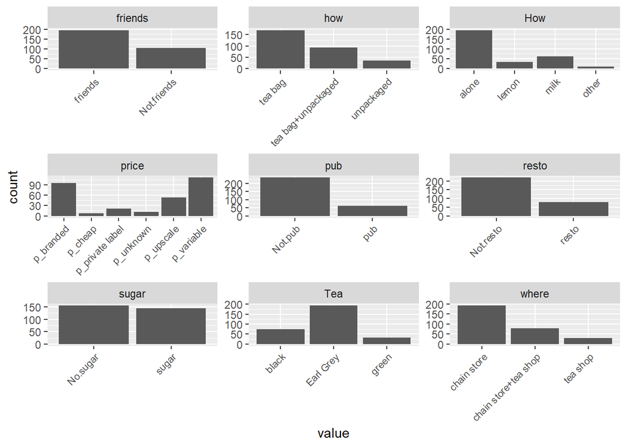

```r
pivot_longer(tea2, cols = everything()) %>%
  ggplot(aes(value)) + facet_wrap("name", scales = "free") + geom_bar() +  theme(axis.text.x = element_text(angle = 45, hjust = 1, size = 8))
```

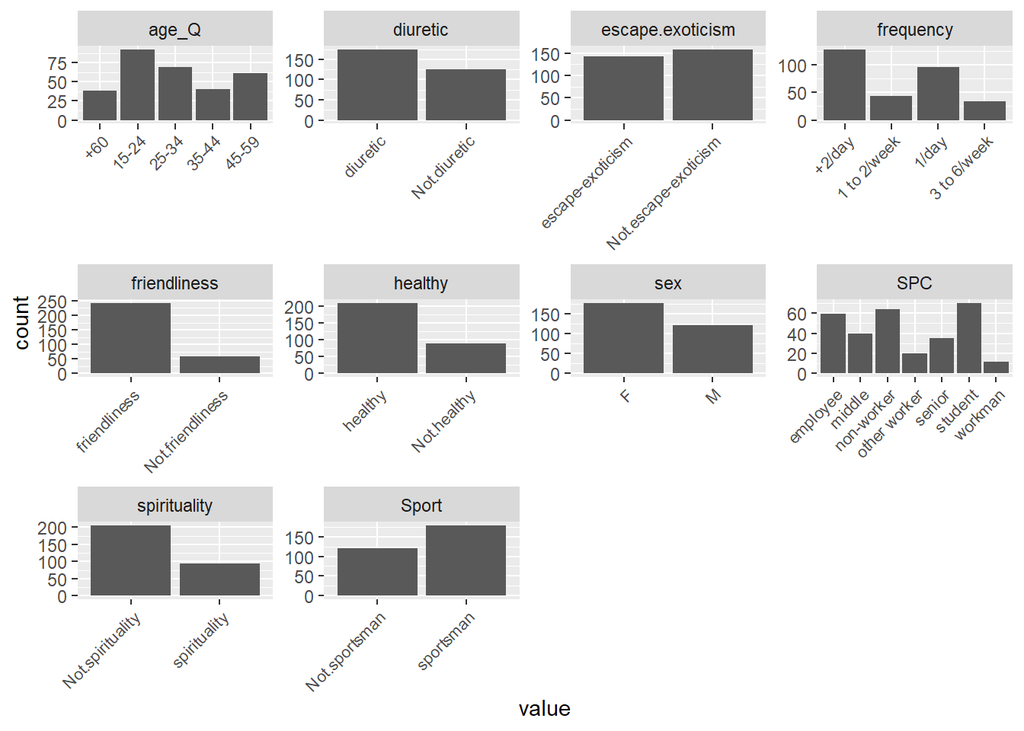

```r
pivot_longer(tea3, cols = everything()) %>%
  ggplot(aes(value)) + facet_wrap("name", scales = "free") + geom_bar() +  theme(axis.text.x = element_text(angle = 45, hjust = 1, size = 8))
```

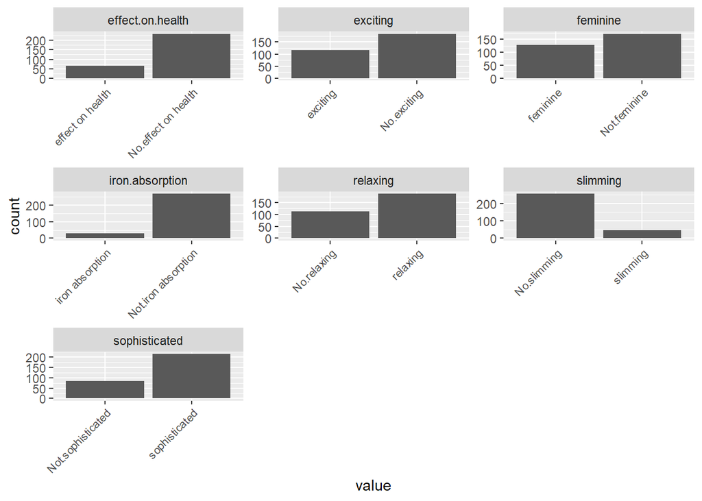

```r
pivot_longer(tea4, cols = everything()) %>%
  ggplot(aes(value)) + facet_wrap("name", scales = "free") + geom_bar() +  theme(axis.text.x = element_text(angle = 45, hjust = 1, size = 8))
```

Data consists of 300 observations and 36 variables. Questionnaire data about how people drink their tea (18 items), how they perceive the product (12 items), and personal details (4 items).

## Multiple correspondence analysis (MCA)

I chose variables Tea, How, sugar, age_Q, and sex.

```r
library(FactoMineR)
library(tidyr)

# column names to keep in the dataset
keep_columns <- c("Tea", "How", "sugar", "age_Q", "sex")

# select the 'keep_columns' to create a new dataset
tea_time <- select(tea, keep_columns)
```

```r
# multiple correspondence analysis
mca <- MCA(tea_time, graph = FALSE)

# summary of the model
summary(mca)
```

```
##
## Call:
## MCA(X = tea_time, graph = FALSE)
##
##
## Eigenvalues
##                        Dim.1   Dim.2   Dim.3   Dim.4   Dim.5   Dim.6   Dim.7
## Variance               0.325   0.279   0.248   0.228   0.205   0.188   0.182
## % of var.             14.777  12.672  11.277  10.365   9.335   8.528   8.292
## Cumulative % of var.  14.777  27.449  38.726  49.091  58.426  66.954  75.246
##                        Dim.8   Dim.9  Dim.10  Dim.11
## Variance               0.165   0.149   0.120   0.111
## % of var.              7.491   6.765   5.461   5.037
## Cumulative % of var.  82.738  89.503  94.963 100.000
##
## Individuals (the 10 first)
##              Dim.1    ctr   cos2    Dim.2    ctr   cos2    Dim.3    ctr   cos2
## 1         |  0.270  0.075  0.029 |  0.535  0.342  0.113 |  0.244  0.080  0.024
## 2         |  0.983  0.990  0.391 | -0.191  0.043  0.015 | -0.248  0.082  0.025
## 3         |  0.309  0.098  0.072 | -0.733  0.643  0.405 | -0.444  0.264  0.148
## 4         | -0.745  0.570  0.472 |  0.004  0.000  0.000 |  0.176  0.042  0.026
## 5         |  0.214  0.047  0.031 | -0.170  0.035  0.020 | -0.606  0.493  0.248
## 6         | -0.307  0.097  0.082 | -0.273  0.089  0.065 | -0.077  0.008  0.005
## 7         |  0.143  0.021  0.010 |  0.004  0.000  0.000 | -0.109  0.016  0.006
## 8         |  0.912  0.852  0.278 | -0.016  0.000  0.000 |  0.249  0.083  0.021
## 9         |  0.252  0.065  0.024 |  0.292  0.102  0.032 | -0.014  0.000  0.000
## 10        |  0.708  0.514  0.201 |  0.258  0.080  0.027 | -0.009  0.000  0.000
##
## 1         |
## 2         |
## 3         |
## 4         |
## 5         |
## 6         |
## 7         |
## 8         |
## 9         |
## 10        |
##
## Categories (the 10 first)
```

[output cut: 15 more lines]

```
## alone      -0.262   3.589   0.127  -6.167 |
## lemon       0.842   6.280   0.088   5.116 |
## milk       -0.023   0.009   0.000  -0.209 |
## other       2.749  18.270   0.234   8.358 |
## No.sugar   -0.305   3.867   0.099  -5.448 |
## sugar       0.326   4.134   0.099   5.448 |
## +60         0.907   8.407   0.119   5.975 |
##
## Categorical variables (eta2)
##             Dim.1 Dim.2 Dim.3
## Tea       | 0.481 0.106 0.313 |
## How       | 0.172 0.177 0.349 |
## sugar     | 0.390 0.133 0.099 |
## age_Q     | 0.565 0.445 0.440 |
## sex       | 0.018 0.533 0.039 |
```

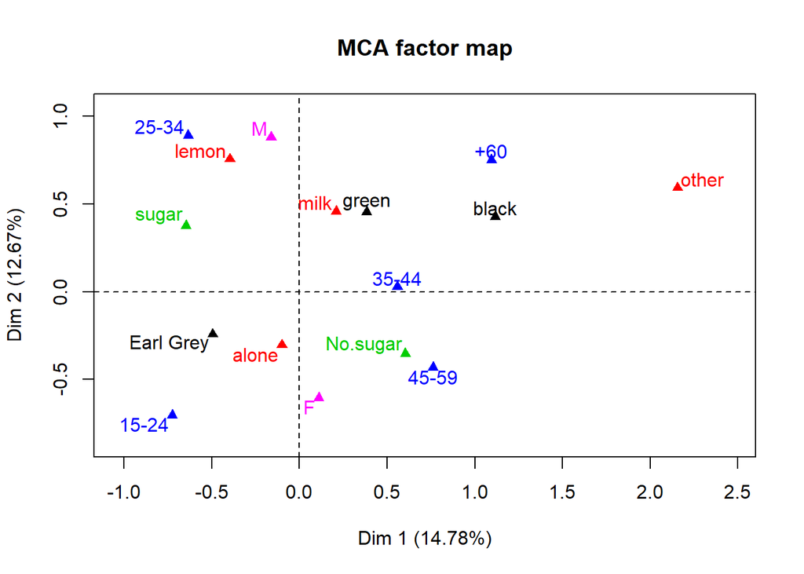

```r
# visualize MCA
plot(mca, invisible=c("ind"), graph.type = "classic", habillage = "quali")
```

People using milk or other things with their tea, favoring green or black tea and being 35-44 or +60 year old have positive effect on both dimension 1 and 2. Choose Earl Grey, not adding anything to tea, and being 15-24 years-old have negative effect on dimensions 1 and 2.

For dim1 gender does not have an effect, but for dim2 there seems to be an opposite effect for gender.

Among these selected variables there does not seem to be any clusters that could clearly explain the variability in the data.